# Small Group Collaboration - Session 2

October 1, 2020

## NYC Flights

```
## Rows: 6
## Columns: 16
## $ year      <int> 2013, 2013, 2013, 2013, 2013, 2013
## $ month     <int> 4, 5, 6, 3, 9, 4
## $ day       <int> 13, 17, 28, 13, 24, 25
## $ dep_time  <int> 903, 1119, 1533, 1700, 1808, 1759
## $ dep_delay <dbl> -2, 19, 8, -1, -2, -1
## $ arr_time  <int> 1019, 1223, 1733, 1959, 1942, 2057
## $ arr_delay <dbl> 0, 13, 8, -11, -3, 22
## $ carrier   <chr> "B6", "MQ", "MQ", "UA", "WN", "DL"
## $ tailnum   <chr> "N178JB", "N6EAMQ", "N528MQ", "N54241", "N248WN", "N623DL"
## $ flight    <int> 56, 3792, 3199, 80, 1368, 61
## $ origin    <chr> "JFK", "JFK", "LGA", "EWR", "LGA", "LGA"
## $ dest      <chr> "BTV", "DCA", "CLT", "MIA", "BNA", "ATL"
## $ air_time  <dbl> 46, 46, 88, 165, 112, 113
## $ distance  <dbl> 266, 213, 544, 1085, 764, 762
## $ hour      <dbl> 9, 11, 15, 17, 18, 17
## $ minute    <dbl> 3, 19, 33, 0, 8, 59
```

## Research Questions & Data Wrangling

Passengers are interested in which month they could expect to have the highest average delay departing from an NYC airport?

**How would you wrangle the data to address this question?**

## Research Questions & Data Wrangling Continued

- Airlines are interested in the arrival delays for flights headed to San Francisco (SFO) in the winter (December, January, February).

  **How would you filter the data to satisfy these criteria?**
- For these flights, they are interested in which carrier has the most variable arrival delays.

  **How would you address this question?**

## Research Questions & Data Visualizations

- What is the distribution of departure delays?

**What type of visualization would you create?**

- How does the distribution of departure delays differ by carrier?

  **How would you modify your previous visualization?**
- How does each carrier’s departure delays differ by month?

  **How would you modify your previous visualization?**

## Effective Data Visualization - Histogram

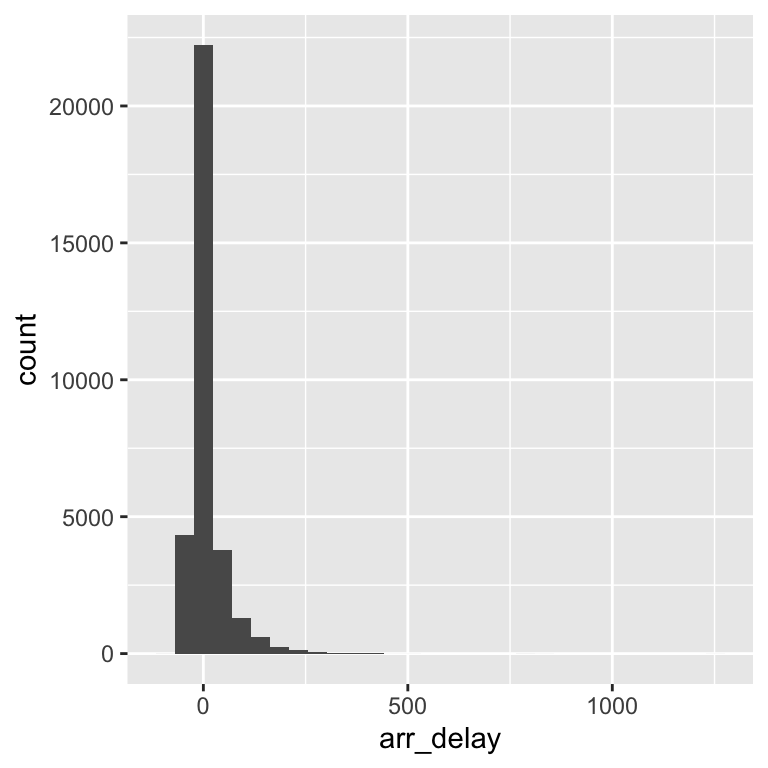

```r
nycflights %>%
  ggplot(aes(x = arr_delay)) +
  geom_histogram()
```

**How would you change the histogram to more effectively communicate the distribution of departure delays?**

## Effective Data Visualization - Boxplot

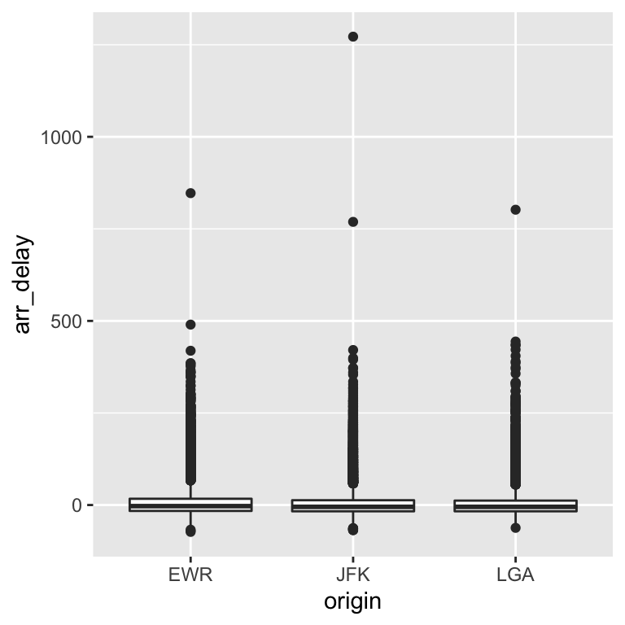

```r
nycflights %>%
  ggplot(aes(y = arr_delay, x = origin)) +
  geom_boxplot()
```

**How would you change the side-by-side boxplots to more effectively communicate how the distribution of departure delays differs by origin?**

## Effective Data Visualization - Scatterplot

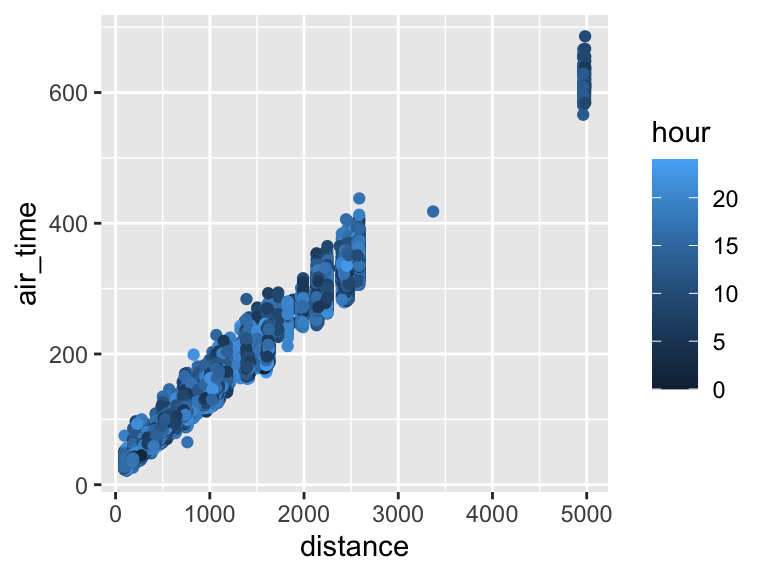

```r
nycflights %>%
  ggplot(aes(x = distance, y = air_time, color = hour)) +
  geom_point()
```

**How would you change the scatterplot to more effectively communicate how the relationship between distance and air time differs by the hour the flight left the airport?**